# Development of strategies to identify and expand asset customers

#### Observations

The variables CCAvg and Income have outliers. Both of these variables have outliers that are upper outliers. One strategy to treat outliers is that the values that are larger than the upper whisker can be given a value that is equal to the value of the upper whisker.

```python
# The functions below are for treating outliers
# First function is for treating a single column
def treat_outliers(df, col):
    """This function treats the outliers by putting all the values greater than the upper whisker
    to be equal to the value of the upper whisker (1.5*IQR)."""
    Q1 = df[col].quantile(0.25)  # 25th quantile
    Q3 = df[col].quantile(0.75)  # 75th quantile
    IQR = Q3 - Q1
    Lower_Whisker = Q1 - 1.5 * IQR
    Upper_Whisker = Q3 + 1.5 * IQR

    # all the values smaller than Lower_Whisker will be assigned the value of Lower_Whisker
    # all the values greater than Upper_Whisker will be assigned the value of Upper_Whisker
    df[col] = np.clip(df[col], Lower_Whisker, Upper_Whisker)

    return df


# Function below is to treat a list of columns
def treat_outliers_all(df, col_list):
    """This function uses the treat_outliers function and applies it to a list of columns"""
    for c in col_list:
        df = treat_outliers(df, c)

    return df
```

```python
# Applying the above two functions to our continous variable columns
numerical_col = loanDataprep.select_dtypes(
    include=["int64", "float64"]
).columns.tolist()
loanDataprep = treat_outliers_all(loanDataprep, numerical_col)
```

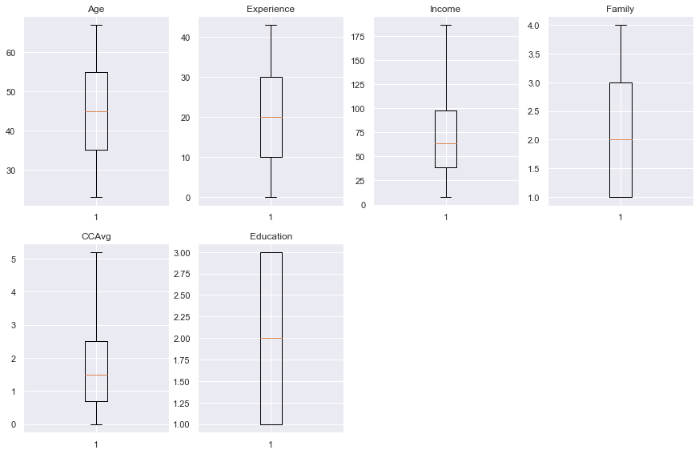

```python
# Plot the boxplots again to check if outliers are fixed
numerical_col = loanDataprep.select_dtypes(
    include=["int64", "float64"]
).columns.tolist()
plt.figure(figsize=(15, 20))

# Make subplots
for i, variable in enumerate(numerical_col):
    plt.subplot(4, 4, i + 1)
    plt.boxplot(loanDataprep[variable], whis=1.5)
    plt.title(variable)

plt.show()
```

#### Observations

From the box plots above, we can see that the outliers for CCAvg and Income variables are fixed.

This concludes the preprocessing section of the analysis.

### 8. Logistic Regression Model

This section has the following subsections:

1. Creating the training and testing data
2. Building the logistic regression model
3. Performance metrics for the logistic regression model
4. Improvement of the logistic regression model

### Note about model predictions

The Personal_Loan is the dependent variable. What we are trying to predict with the logistic regression model is that which of the customers in the data set are likely to take out a personal loan with the bank. That is we are trying to predict which of the customers from the test data set will have Personal_loan = 1 or Personal_loan = 0.

We will use recall and F1 as our most important performance measures.

The wrong predictions will consist of (a) the customer was predicted to take out a personal loan, but did not when the marketing campaign targeted that customer (False Positive) and (b) the customer was predicted to not take a personal loan, but ended up taking a personal loan with the bank (False Negative).

In terms of cost and resources, the false positives (predicted for personal_loan = 1) will be more concerning because the marketing campaign will cost money and resources, and predictions will tie into revenue predictions/strategies as well.

Hence, the model analysis must reduce the occurances of false positives.

We will not focus on accuracy as a performance measure because we know beforehand that the data is not balanced data.

Recall, which is the true positivity rate and precision, which is the specificity/true negative rate are both important and maximzing F1 such that neither recall nor precision suffers, will be the aim.

```python
# 8.1 Creating the training and testing data
# Dependent variable = Personal_loan
X = loanDataprep.drop(
    ["Personal_Loan"], axis=1
)  # Dropping it from independent variable group
Y = loanDataprep["Personal_Loan"]

# X = pd.get_dummies(X, drop_first=True)

# Splitting data in train and test sets
X_train, X_test, y_train, y_test = train_test_split(
    X, Y, test_size=0.10, random_state=1
)
# Note: A more common split is test_size = 0.3. However, as we observed in the EDA
# and preprocessing section, the number of values where Personal_Loan = 1 is tiny as compared
# to the group where Personal_loan = 0. This is because the campaign to convert liability
# customers to asset customers is only one year old. However, we will use a test_size = 0.1
# to facilitate the training set to have more examples of Personal_loan = 1.
```

```python
print("Shape of Training set : ", X_train.shape)
print("Shape of Testing set : ", X_test.shape)
print("Percentage of classes in training set:")
print(y_train.value_counts(normalize=True))
print("Percentage of classes in test set:")
print(y_test.value_counts(normalize=True))
```

```
Shape of Training set :  (4500, 48)
Shape of Testing set :  (500, 48)
Percentage of classes in training set:
0    0.903111
1    0.096889
Name: Personal_Loan, dtype: float64
Percentage of classes in test set:
0    0.912
1    0.088
Name: Personal_Loan, dtype: float64
```

#### Observations

The training and testing split was 90 to 10. This was to allow training set to have more examples of the class where samples were scarce. Thus, 4500 rows were alloted to the training set and 500 rows were alloted to the testing set.

90% of the data in the training set had Personal_loan = 0, and 91% of the testing set had Personal_loan = 0.

```python
# Function to calculate performance metrics for classification models
# threshold = 0.5 for this function
def model_performance_classification_sklearn_with_threshold(
    model, predictors, target, threshold=0.5
):
    """
    Function to compute different metrics, based on the threshold specified, to check classification model performance
    model: classifier
    predictors: independent variables
    target: dependent variable
    threshold: threshold for classifying the observation as class 1
    """

    # predicting using the independent variables
    pred_prob = model.predict_proba(predictors)[:, 1]
    pred_thres = pred_prob > threshold
    pred = np.round(pred_thres)

    acc = accuracy_score(target, pred)  # to compute Accuracy
    recall = recall_score(target, pred)  # to compute Recall
    precision = precision_score(target, pred)  # to compute Precision
    f1 = f1_score(target, pred)  # to compute F1-score

    # creating a dataframe of metrics
    df_perf = pd.DataFrame(
        {
            "Accuracy": acc,
            "Recall": recall,
            "Precision": precision,
            "F1": f1,
        },
        index=[0],
    )

    return df_perf
```

```python
# Function to create the confusion matrix
def confusion_matrix_sklearn_with_threshold(model, predictors, target, threshold=0.5):
    """
    To plot the confusion_matrix, based on the threshold specified, with percentages

    model: classifier
    predictors: independent variables
    target: dependent variable
    threshold: threshold for classifying the observation as class 1
    """
    pred_prob = model.predict_proba(predictors)[:, 1]
    pred_thres = pred_prob > threshold
    y_pred = np.round(pred_thres)

    cm = confusion_matrix(target, y_pred)
    labels = np.asarray(
        [
            ["{0:0.0f}".format(item) + "\n{0:.2%}".format(item / cm.flatten().sum())]
            for item in cm.flatten()
        ]
    ).reshape(2, 2)

    plt.figure(figsize=(6, 4))
    sns.heatmap(cm, annot=labels, fmt="")
    plt.ylabel("True label")
    plt.xlabel("Predicted label")
```

```python
# Building the logistic regression model
# Using newton-cg solver as it is faster
# Choosing random_state = 1 so that it initializes at same state every time
# the cell is executed

lg = LogisticRegression(solver="newton-cg", random_state=1)
model = lg.fit(X_train, y_train)
```

```python
# Calculating the coefficients and intercept for the logistic model with threshold 0.5
coef_df = pd.DataFrame(
    np.append(lg.coef_, lg.intercept_),
    index=X_train.columns.tolist() + ["Intercept"],
    columns=["Coefficients"],
)
coef_df.T
```

|  | Age | Experience | Income | Family | CCAvg | Education | Mortgage | Securities_Account | CD_Account | Online | CreditCard | County_Butte County | County_Contra Costa County | County_El Dorado County | County_Fresno County | County_Humboldt County | County_Imperial County | County_Kern County | County_Lake County | County_Los Angeles County | County_Marin County | County_Mendocino County | County_Merced County | County_Monterey County | County_Napa County | County_Orange County | County_Placer County | County_Riverside County | County_Sacramento County | … |
| --- | --- | --- | --- | --- | --- | --- | --- | --- | --- | --- | --- | --- | --- | --- | --- | --- | --- | --- | --- | --- | --- | --- | --- | --- | --- | --- | --- | --- | --- | --- |
| Coefficients | -0.02676 | 0.038658 | 0.056867 | 0.726818 | 0.314888 | 1.813045 | 0.154965 | -0.716255 | 3.277246 | -0.590256 | -0.965135 | 0.284472 | 0.754902 | -0.129912 | -0.241262 | -0.245766 | -0.017528 | 0.456199 | -0.004414 | 0.122244 | 0.682963 | -0.029562 | -0.24198 | 0.194002 | -0.004344 | -0.034489 | 0.449075 | 0.622044 | 0.031816 | … |

#### Observations

Coefficients that are positive include Family, Income, CCAvg and a couple of counties. An increase in these values of variables will likely increase the chances of a customer having Personal_Loan = 1.

```python
# Since the coefficients are for logistic regression, we have to take the exponent
# to find the odds.

# converting coefficients to odds
odds = np.exp(lg.coef_[0])

# finding the percentage change
perc_change_odds = (np.exp(lg.coef_[0]) - 1) * 100

# adding the odds to a dataframe
pd.DataFrame({"Odds": odds, "Change_odd%": perc_change_odds}, index=X_train.columns).T
```

|  | Age | Experience | Income | Family | CCAvg | Education | Mortgage | Securities_Account | CD_Account | Online | CreditCard | County_Butte County | County_Contra Costa County | County_El Dorado County | County_Fresno County | County_Humboldt County | County_Imperial County | County_Kern County | County_Lake County | County_Los Angeles County | County_Marin County | County_Mendocino County | County_Merced County | County_Monterey County | County_Napa County | County_Orange County | County_Placer County | County_Riverside County | County_Sacramento County | … |
| --- | --- | --- | --- | --- | --- | --- | --- | --- | --- | --- | --- | --- | --- | --- | --- | --- | --- | --- | --- | --- | --- | --- | --- | --- | --- | --- | --- | --- | --- | --- |
| Odds | 0.973595 | 1.039415 | 1.058515 | 2.068488 | 1.370106 | 6.129081 | 1.167617 | 0.488578 | 26.502692 | 0.554186 | 0.380932 | 1.329061 | 2.127403 | 0.878173 | 0.785636 | 0.782105 | 0.982625 | 1.578064 | 0.995596 | 1.130030 | 1.979735 | 0.97087 | 0.785072 | 1.214098 | 0.995665 | 0.966099 | 1.566862 | 1.862731 | 1.032328 | … |
| Change_odd% | -2.640498 | 3.941478 | 5.851519 | 106.848784 | 37.010612 | 512.908062 | 16.761700 | -51.142164 | 2550.269155 | -44.581449 | -61.906820 | 32.906053 | 112.740268 | -12.182701 | -21.436392 | -21.789477 | -1.737481 | 57.806415 | -0.440424 | 13.003012 | 97.973452 | -2.91296 | -21.492835 | 21.409839 | -0.433485 | -3.390107 | 56.686203 | 86.273066 | 3.232753 | … |

#### Observations

For Age variable, if all other features were considered constant, a 1 unit change in Age will decrease the odds of the customer taking out a personal loan (i.e. Personal_Loan = 1). In percentages, this is -2.6%.

For Experience variable, if all other features were considered constant, a 1 unit change in Experience value will increase the odds of the customer taking a personal loan.

The same is true for Income, Family, CCAvg, Education, Mortgage, CD_ACcount, and true for some counties.

Variables such as Securities_Account, Online and CreditCard will behave the same way as Age variable meaning a 1 unit change in their value will decrease the odds of customer taking out a loan.

#### Confusion Matrix and Performance evaluation for model with 0.5 threshold

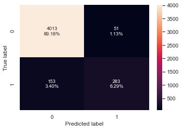

```python
# For a threshold of 0.5, the confusion matrix is below for training data
confusion_matrix_sklearn_with_threshold(lg, X_train, y_train)
```

#### Observations

1. The true positives (Predicted label = 1, True label = 1) = 6.29 %
2. The above is for Personal_Loan to have a value of "1". As we saw in the data, the sample size for Personal_Loan is just 9.5% of the data, so the number of examples in the training data set is quite low. This can impact the model performance for true positives.
4. The true negatives (Predicted label = 0, True label = 0) = 89.18%
5. 90% of the data was Personal_Loan = 0, so it is expected that the model will perform well for the true negatives.
6. False positives = 1.13% and False negatives = 3.4%.
7. In our case, the false positives will cost more in terms of resources, so 1% on training set is good performance of the model.

```python
# Calculating the performance metrics for the model performance for threshold of 0.5
log_reg_model_train_perf = model_performance_classification_sklearn_with_threshold(
    lg, X_train, y_train
)

print("Training performance:")
log_reg_model_train_perf
```

```
Training performance:
```

|  | Accuracy | Recall | Precision | F1 |
| --- | --- | --- | --- | --- |
| 0 | 0.954667 | 0.649083 | 0.847305 | 0.735065 |

#### Observations

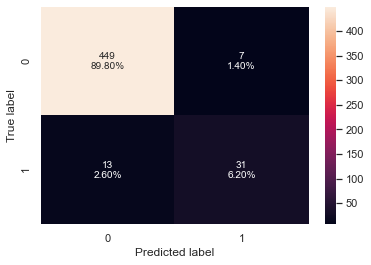

```python
# Generating confusion matrix for the test data set
confusion_matrix_sklearn_with_threshold(lg, X_test, y_test)
```

#### Observations

1. The true positives (Predicted label = 1, True label = 1) = 6.2 % (very close to training set performance for true positives).
2. The above is for Personal_Loan to have a value of "1". As we saw in the data, the sample size for Personal_Loan is just 9.5% of the data, so the number of examples in the training data set is quite low. This can impact the model performance for the testing set as well for true positives.
4. The true negatives (Predicted label = 0, True label = 0) = 89.8%
5. 90% of the data was Personal_Loan = 0, so it is expected that the model will perform well for the true negatives.
6. False positives = 1.4% and False negatives = 2.6%.
7. These values are similar to the values in the confusion matrix for the training data set.

```python
# Calculating performance metrics on the testing data set
log_reg_model_test_perf = model_performance_classification_sklearn_with_threshold(
    lg, X_test, y_test
)

print("Test set performance:")
log_reg_model_test_perf
```

```
Test set performance:
```

|  | Accuracy | Recall | Precision | F1 |
| --- | --- | --- | --- | --- |
| 0 | 0.96 | 0.704545 | 0.815789 | 0.756098 |

#### Observations

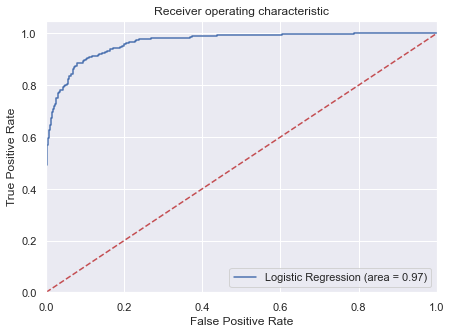

```python
# We will use the ROC curve for analysis
logit_roc_auc_train = roc_auc_score(y_train, lg.predict_proba(X_train)[:, 1])
fpr, tpr, thresholds = roc_curve(y_train, lg.predict_proba(X_train)[:, 1])
plt.figure(figsize=(7, 5))
plt.plot(fpr, tpr, label="Logistic Regression (area = %0.2f)" % logit_roc_auc_train)
plt.plot([0, 1], [0, 1], "r--")
plt.xlim([0.0, 1.0])
plt.ylim([0.0, 1.05])
plt.xlabel("False Positive Rate")
plt.ylabel("True Positive Rate")
plt.title("Receiver operating characteristic")
plt.legend(loc="lower right")
plt.show()
```

#### Observations

Ideally, we would want a high value for true positive rate and a low false positive rate at the same time. We can observe that there is a large area under the blue curve, which is the model with the 0.5 threshold.

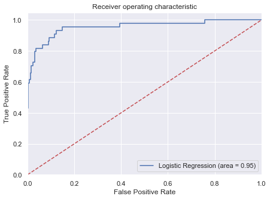

```python
# ROC curve for testing data
logit_roc_auc_test = roc_auc_score(y_test, lg.predict_proba(X_test)[:, 1])
fpr, tpr, thresholds = roc_curve(y_test, lg.predict_proba(X_test)[:, 1])
plt.figure(figsize=(7, 5))
plt.plot(fpr, tpr, label="Logistic Regression (area = %0.2f)" % logit_roc_auc_test)
plt.plot([0, 1], [0, 1], "r--")
plt.xlim([0.0, 1.0])
plt.ylim([0.0, 1.05])
plt.xlabel("False Positive Rate")
plt.ylabel("True Positive Rate")
plt.title("Receiver operating characteristic")
plt.legend(loc="lower right")
plt.show()
```

#### Observation

We can see that the area under the curve for testing ROC and training ROC are close to each other.

```python
# For improvement of the model, we will calculate the threshold using AUC-ROC strategy
# Optimal threshold as per AUC-ROC curve
# The optimal cut off would be where tpr is high and fpr is low
fpr, tpr, thresholds = roc_curve(y_train, lg.predict_proba(X_train)[:, 1])

optimal_idx = np.argmax(tpr - fpr)
optimal_threshold_auc_roc = thresholds[optimal_idx]
print(optimal_threshold_auc_roc)
```

```
0.13716269004907247
```

#### Observations

Using the area under the curve for the ROC curve, such that the true positivity rate will remain high, while the false positivity rate will remain low, the threshold is found to be 0.137.

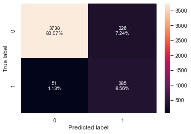

```python
# Generating confusion matrix for training data for threshold of 0.137
confusion_matrix_sklearn_with_threshold(
    lg, X_train, y_train, threshold=optimal_threshold_auc_roc
)
```

#### Observations

1. The true positives (Predicted label = 1, True label = 1) = 8.56%. When the threshold was 0.5, the true positives was 6.29%. Thus, the threshold found via the ROC curve is giving better performance on the training data set.
2. The true negatives (Predicted label = 0, True label = 0) = 83.07%
3. This is sort of comparable to the threshold being 0.5 where it was 89% for true negatives.
4. False positives = 7.24% and False negatives = 1.13%.
5. These values are not similar to the threshold being 0.5 for training set earlier. The earlier numbers were 1.13% and 3.4% for the training data set. While the false negatives has reduces, the false positives has gone up.

```python
# checking model performance for this model on training data with threshold = 0.137
log_reg_model_train_perf_threshold_auc_roc = (
    model_performance_classification_sklearn_with_threshold(
        lg, X_train, y_train, threshold=optimal_threshold_auc_roc
    )
)
print("Training performance:")
log_reg_model_train_perf_threshold_auc_roc
```

```
Training performance:
```

|  | Accuracy | Recall | Precision | F1 |
| --- | --- | --- | --- | --- |
| 0 | 0.916222 | 0.883028 | 0.541491 | 0.671316 |

#### Observations

For a threshold of 0.137, the model performance on the training data set was 88% for the recall, 54% for the precision and F1 is 67%.

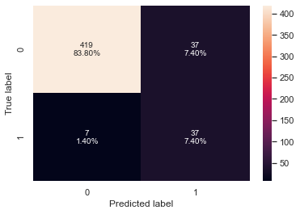

```python
# Generating confusion matrix for testing data set with threshold = 0.137
confusion_matrix_sklearn_with_threshold(
    lg, X_test, y_test, threshold=optimal_threshold_auc_roc
)
```

#### Observations

```python
# checking model performance for this model on testing data set with threshold = 0.137
log_reg_model_test_perf_threshold_auc_roc = (
    model_performance_classification_sklearn_with_threshold(
        lg, X_test, y_test, threshold=optimal_threshold_auc_roc
    )
)
print("Test set performance:")
log_reg_model_test_perf_threshold_auc_roc
```

```
Test set performance:
```

|  | Accuracy | Recall | Precision | F1 |
| --- | --- | --- | --- | --- |
| 0 | 0.912 | 0.840909 | 0.5 | 0.627119 |

#### Observations

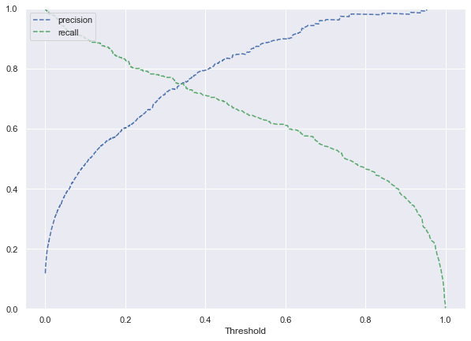

```python
# We will attempt the Precision-Recall curve to find a better threshold
y_scores = lg.predict_proba(X_train)[:, 1]
prec, rec, tre = precision_recall_curve(
    y_train,
    y_scores,
)


def plot_prec_recall_vs_tresh(precisions, recalls, thresholds):
    plt.plot(thresholds, precisions[:-1], "b--", label="precision")
    plt.plot(thresholds, recalls[:-1], "g--", label="recall")
    plt.xlabel("Threshold")
    plt.legend(loc="upper left")
    plt.ylim([0, 1])


plt.figure(figsize=(10, 7))
plot_prec_recall_vs_tresh(prec, rec, tre)
plt.show()
```

#### Observations

From above, we can observe that at higher thresholds, the recall dips. While at higher thresholds, the precision improves. We will use a threshold - say 0.35 - to get a balance between the recall and the precision. This will help us get a reasonable F1 score.

```python
# Choosing threshold based on graph above
optimal_threshold_curve = 0.35
```

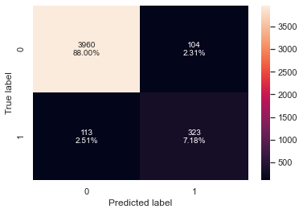

```python
# Generating confusion matrix with threshold 0.35 for training data set
confusion_matrix_sklearn_with_threshold(
    lg, X_train, y_train, threshold=optimal_threshold_curve
)
```

#### Observations

1. The true positives (Predicted label = 1, True label = 1) = 7.18%.
2. The true negatives (Predicted label = 0, True label = 0) = 88%
3. False positives = 2.31% and False negatives = 2.51%.
4. These values are comparable to the training data set.

```python
# Generating performance metrics for training data set with threshold = 0.35
log_reg_model_train_perf_threshold_curve = (
    model_performance_classification_sklearn_with_threshold(
        lg, X_train, y_train, threshold=optimal_threshold_curve
    )
)
print("Training performance:")
log_reg_model_train_perf_threshold_curve
```

```
Training performance:
```

|  | Accuracy | Recall | Precision | F1 |
| --- | --- | --- | --- | --- |
| 0 | 0.951778 | 0.740826 | 0.75644 | 0.748552 |

#### Observations

For a threshold of 0.35, the model performance on the training data set was 74% for the recall, 75.6% for the precision and F1 is 74.8%.

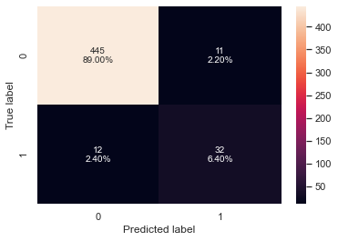

```python
# Generating confusion matrix for testing data set with threshold 0.35
confusion_matrix_sklearn_with_threshold(
    lg, X_test, y_test, threshold=optimal_threshold_curve
)
```

#### Observations

```python
# Generating performance metrics for testing data with threshold 0.35
log_reg_model_test_perf_threshold_curve = (
    model_performance_classification_sklearn_with_threshold(
        lg, X_test, y_test, threshold=optimal_threshold_curve
    )
)
print("Test set performance:")
log_reg_model_test_perf_threshold_curve
```

```
Test set performance:
```

|  | Accuracy | Recall | Precision | F1 |
| --- | --- | --- | --- | --- |
| 0 | 0.954 | 0.727273 | 0.744186 | 0.735632 |

#### Observations

```python
# We will try feature selection to see if we can improve the threshold
# Fit the model on train
model = LogisticRegression(solver="newton-cg", n_jobs=-1, random_state=1, max_iter=100)
```

```python
# we will first build model with all varaible
sfs = SFS(
    model,
    k_features=48,
    forward=True,
    floating=False,
    scoring="f1",
    verbose=2,
    cv=3,
    n_jobs=-1,
)

sfs = sfs.fit(X_train, y_train)
```

[output not shown]

[output cut: 127 more lines]

[output not shown]

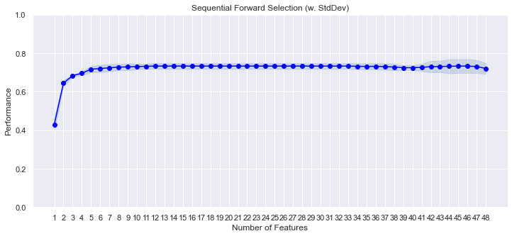

```python
fig1 = plot_sfs(sfs.get_metric_dict(), kind="std_dev", figsize=(12, 5))
plt.ylim([0, 1])
plt.title("Sequential Forward Selection (w. StdDev)")
# plt.xticks(rotation=90)
plt.show()
```

#### Observations

After features 1-9, the gain in performance (evaluated based on F1 in this analysis) is negligible. We shall take the higher value - 9 for the logistic regression model being built on the basis of feature selection.

[output not shown]

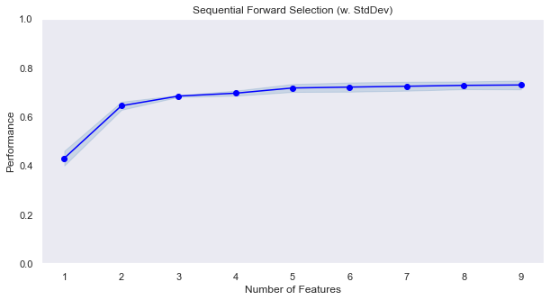

```python
# Build again, but this time with k_features = 9
sfs1 = SFS(
    model,
    k_features=9,
    forward=True,
    floating=False,
    scoring="f1",
    verbose=2,
    cv=3,
    n_jobs=-1,
)

sfs1 = sfs1.fit(X_train, y_train)

fig1 = plot_sfs(sfs1.get_metric_dict(), kind="std_dev", figsize=(10, 5))

plt.ylim([0, 1])
plt.title("Sequential Forward Selection (w. StdDev)")
plt.grid()
plt.show()
```

```python
# This will tell us which feature numbers were important so we can use it for model
feature_cols = list(sfs1.k_feature_idx_)
print(feature_cols)
```

```
[2, 3, 5, 7, 8, 10, 19, 35, 41]
```

#### Observations

Using the feature selector, we can see that the F1 is likely to be below 80%.

```python
# The features mentioned above are:
X_train.columns[feature_cols]
```

```
Index(['Income', 'Family', 'Education', 'Securities_Account', 'CD_Account',
       'CreditCard', 'County_Los Angeles County', 'County_San Mateo County',
       'County_Solano County'],
      dtype='object')
```

```python
# Using the above feature columns to set up training and testing data
X_train_final = X_train[X_train.columns[feature_cols]]
X_test_final = X_test[X_train_final.columns]
```

```python
# Fitting logistic regession model

logreg = LogisticRegression(
    solver="newton-cg", penalty="none", verbose=True, n_jobs=-1, random_state=0
)

# There are several optimizer, we are using optimizer called as 'newton-cg' with max_iter equal to 10000
# max_iter indicates number of iteration needed to converge

logreg.fit(X_train_final, y_train)
```

```
[Parallel(n_jobs=-1)]: Using backend LokyBackend with 8 concurrent workers.
[Parallel(n_jobs=-1)]: Done   1 out of   1 | elapsed:    0.4s finished
```

```
LogisticRegression(n_jobs=-1, penalty='none', random_state=0,
                   solver='newton-cg', verbose=True)
```

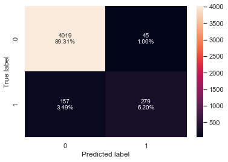

```python
# Generating confusion matrix for training data with SFS features
confusion_matrix_sklearn_with_threshold(logreg, X_train_final, y_train)
```

#### Observations

1. The true positives (Predicted label = 1, True label = 1) = 6.2%.
2. The true negatives (Predicted label = 0, True label = 0) = 89.31%
3. False positives = 1% and False negatives = 3.49%.

```python
# Generating the performance metrics for SFS model for training data
log_reg_model_train_perf_SFS = model_performance_classification_sklearn_with_threshold(
    logreg, X_train_final, y_train
)
print("Training performance:")
log_reg_model_train_perf_SFS
```

```
Training performance:
```

|  | Accuracy | Recall | Precision | F1 |
| --- | --- | --- | --- | --- |
| 0 | 0.955111 | 0.639908 | 0.861111 | 0.734211 |

#### Observations

For 9 features , the model performance on the training data set was 63.9% for the recall, 86.1% for the precision and F1 is 73.4%.

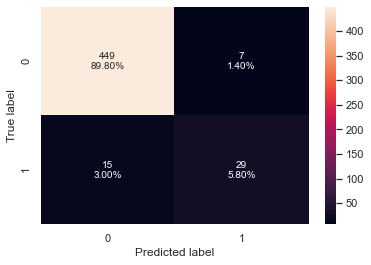

```python
# Generating confusion matrix for the SFS model with testing data
confusion_matrix_sklearn_with_threshold(logreg, X_test_final, y_test)
```

#### Observations

1. The true positives (Predicted label = 1, True label = 1) = 5.8%.
2. The true negatives (Predicted label = 0, True label = 0) = 89.8%
3. False positives = 1.4% and False negatives = 3%.

```python
# Generating performance metrics for SFS model for testing data
log_reg_model_test_perf_SFS = model_performance_classification_sklearn_with_threshold(
    logreg, X_test_final, y_test
)
print("Test set performance:")
log_reg_model_test_perf_SFS
```

```
Test set performance:
```

|  | Accuracy | Recall | Precision | F1 |
| --- | --- | --- | --- | --- |
| 0 | 0.956 | 0.659091 | 0.805556 | 0.725 |

#### Observations

For 9 features , the model performance on the testing data set was 65.9% for the recall, 80.5% for the precision and F1 is 72.5%.

```python
# This makes a table that puts all the 4 models we built for training - the 0.5 threshold, the threshold
# based on AUC (0.137), the threshold based on Precision-Recall curve (0.35), and the model
# where number of features is 9 (based on feature selection) instead of 48.

models_train_comp_df = pd.concat(
    [
        log_reg_model_train_perf.T,
        log_reg_model_train_perf_threshold_auc_roc.T,
        log_reg_model_train_perf_threshold_curve.T,
        log_reg_model_train_perf_SFS.T,
    ],
    axis=1,
)
models_train_comp_df.columns = [
    "Logistic Regression sklearn",
    "Logistic Regression-0.137 Threshold",
    "Logistic Regression-0.35 Threshold",
    "Logistic Regression - SFS",
]
print("Training performance comparison:")
models_train_comp_df
```

```
Training performance comparison:
```

|  | Logistic Regression sklearn | Logistic Regression-0.137 Threshold | Logistic Regression-0.35 Threshold | Logistic Regression - SFS |
| --- | --- | --- | --- | --- |
| Accuracy | 0.954667 | 0.916222 | 0.951778 | 0.955111 |
| Recall | 0.649083 | 0.883028 | 0.740826 | 0.639908 |
| Precision | 0.847305 | 0.541491 | 0.756440 | 0.861111 |
| F1 | 0.735065 | 0.671316 | 0.748552 | 0.734211 |

#### Observations

1. We will ignore the accuracy measure here - because it is an imbalanced data set - because 90% of the data is Personal_Loan = 0, the model will end up having accuracy of approximately 90% even if it predicts every single customer has Personal_Loan = 0.
2. There is one instance where the recall is greater than 80% - it is for the model that used area under the curve for ROC curve to decide a threshold. The recall is the true positivity rate/sensitivity so 88% is a good value for recall.For a threshold of 0.5, and for 9 features, the recall drops to 63%.
3. The precision is above 80% twice - for a threshold of 0.5, and for features used = 9.The precision is the true negativity rate/specificity so ideally we would like precision to be high.
4. The F1 score - which is based on recall as well as precision but can be pulled down by either having a low score - is highest (74.8%) when the precision-recall curve is used to estimate a threshold.
5. To decide which model is most reasonable in terms of performance, and keeping in mind, that we want to reduce false positives - the model where the threshold is 0.35 (chosen based on precision-recall curves) such that recall and precision and F1 that are close to each other and approximately 75%.
6. The false positives = 2.31% and false negatives = 2.51% for the training data when the threshold is 0.35.

```python
# This makes a table that puts all the 4 models we built for training - the 0.5 threshold, the threshold
# based on AUC (0.137), the threshold based on Precision-Recall curve (0.35), and the model
# where number of features is 9 (based on feature selection) instead of 48.

models_test_comp_df = pd.concat(
    [
        log_reg_model_test_perf.T,
        log_reg_model_test_perf_threshold_auc_roc.T,
        log_reg_model_test_perf_threshold_curve.T,
        log_reg_model_test_perf_SFS.T,
    ],
    axis=1,
)
models_test_comp_df.columns = [
    "Logistic Regression sklearn",
    "Logistic Regression-0.137 Threshold",
    "Logistic Regression-0.35 Threshold",
    "Logistic Regression - SFS",
]
print("Test set performance comparison:")
models_test_comp_df
```

```
Test set performance comparison:
```

|  | Logistic Regression sklearn | Logistic Regression-0.137 Threshold | Logistic Regression-0.35 Threshold | Logistic Regression - SFS |
| --- | --- | --- | --- | --- |
| Accuracy | 0.960000 | 0.912000 | 0.954000 | 0.956000 |
| Recall | 0.704545 | 0.840909 | 0.727273 | 0.659091 |
| Precision | 0.815789 | 0.500000 | 0.744186 | 0.805556 |
| F1 | 0.756098 | 0.627119 | 0.735632 | 0.725000 |

#### Observations

The observations made for the training performance metrics also hold for the testing performance metrics. Overall, we want to maximize F1 but also have reasonable recall and precision metrics. Based on the above table for the testing data set, the logistic threshold model with the 0.35 threshold (chosen based on precision-recall curves) has an F1 of 73.5% with a recall of 72.7% and precision of 74.4%. These numbers are comparable to the training performance for the model with the threshold of 0.35 as well.

### 8. Decision Tree Model

This section has the following subsections:

1. Building the decision tree model (the training and testing data will be reused from logistic model section
2. Performance metrics for the decision tree
3. Improvement of the decision tree model

```python
#We will be reusing the training and testing data set from the logistic regression section
print("Number of rows in train data =", X_train.shape[0])
print("Number of rows in test data =", X_test.shape[0])
```

```
Number of rows in train data = 4500
Number of rows in test data = 500
```

#### Observations

Being an imbalanced data set, the data is split 90-10%.

```python
print("Percentage of classes in training set:")
print(y_train.value_counts(normalize=True))
print("Percentage of classes in test set:")
print(y_test.value_counts(normalize=True))
```

```
Percentage of classes in training set:
0    0.903111
1    0.096889
Name: Personal_Loan, dtype: float64
Percentage of classes in test set:
0    0.912
1    0.088
Name: Personal_Loan, dtype: float64
```

```python
# Building of the decision tree model - we will use the default 'gini' criteria
# Weightage is used as {0:10,1:0.9} - this is used to specify the weight of each class
model = DecisionTreeClassifier(
    criterion="gini", class_weight={0: 0.10, 1: 0.9}, random_state=1
)
```

```python
model.fit(X_train, y_train)
```

```
DecisionTreeClassifier(class_weight={0: 0.1, 1: 0.9}, random_state=1)
```

```python
##  Function to calculate accuracy, recall, precision and F1 (no threshold)
def model_performance_classification_sklearn(model, predictors, target):
    """
    model: classifier
    predictors: independent variables
    target: dependent variable

    """
    pred = model.predict_proba(predictors)[:, 1]
    acc = accuracy_score(target, pred)  # to compute Accuracy
    recall = recall_score(target, pred)  # to compute Recall
    precision = precision_score(target, pred)  # to compute Precision
    f1 = f1_score(target, pred)  # to compute F1-score

    # creating a dataframe of metrics
    df_perf = pd.DataFrame(
        {
            "Accuracy": acc,
            "Recall": recall,
            "Precision": precision,
            "F1": f1,
        },
        index=[0],
    )

    return df_perf
```

```python
# We will use a function for confusion matrix which does not use a threshold
def confusion_matrix_sklearn(model, predictors, target):
    """
    To plot the confusion_matrix with percentages

    model: classifier
    predictors: independent variables
    target: dependent variable
    """
    y_pred = model.predict(predictors)
    cm = confusion_matrix(target, y_pred)
    labels = np.asarray(
        [
            ["{0:0.0f}".format(item) + "\n{0:.2%}".format(item / cm.flatten().sum())]
            for item in cm.flatten()
        ]
    ).reshape(2, 2)

    plt.figure(figsize=(6, 4))
    sns.heatmap(cm, annot=labels, fmt="")
    plt.ylabel("True label")
    plt.xlabel("Predicted label")
```

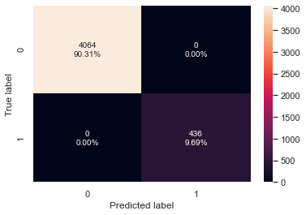

```python
# Generating the confusion matrix for decision tree model for training data set
confusion_matrix_sklearn(model, X_train, y_train)
```

#### Observations

1. The true positives (Predicted label = 1, True label = 1) = 9.69%.
2. The true negatives (Predicted label = 0, True label = 0) = 90.31%
3. False positives = 0% and False negatives = 0%.
4. At first glance, we can see that the decision tree has no false positives or false negatives.

```python
#Generating the performance metrics on the training data set
decision_tree_perf_train = model_performance_classification_sklearn(
    model, X_train, y_train
)

print("Training performance:")
decision_tree_perf_train
```

```
Training performance:
```

|  | Accuracy | Recall | Precision | F1 |
| --- | --- | --- | --- | --- |
| 0 | 1.0 | 1.0 | 1.0 | 1.0 |

#### Observations

A recall, precision and F1 score of 1 indicates that the model classified the training data set correctly for all the data points. No errors (meaning no false positives, and no false negatives) are found for the training data set.

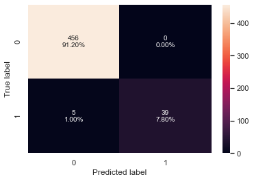

```python
# Generating confusion matrix for decision tree model on testing data set
confusion_matrix_sklearn(model, X_test, y_test)
```

#### Observations

1. The true positives (Predicted label = 1, True label = 1) = 7.8%.
2. The true negatives (Predicted label = 0, True label = 0) = 91.2%
3. False positives = 0% and False negatives = 1%.
4. The decision tree model, while having a perfect performance metric for the training data set, is not able to reproduce the same performance metrics for the test data set. This indicates that the model may have overfitted the training model (meaning it will information+noise in the data).

```python
#Generating the performance metrics on the testing data set
decision_tree_perf_test = model_performance_classification_sklearn(model, X_test, y_test)
print("Testing performance:")
decision_tree_perf_test
```

```
Testing performance:
```

|  | Accuracy | Recall | Precision | F1 |
| --- | --- | --- | --- | --- |
| 0 | 0.99 | 0.886364 | 1.0 | 0.939759 |

#### Observations

The precision score is 1, however recall is 88% and F1 is 93% for the testing set. At first glance, these numbers - while not as good as the training set performance metrics - they are much better than the logistic regression performance model metrics.

```python
# Visualization of the decision tree

## creating a list of column names
feature_names = X_train.columns.to_list()
```

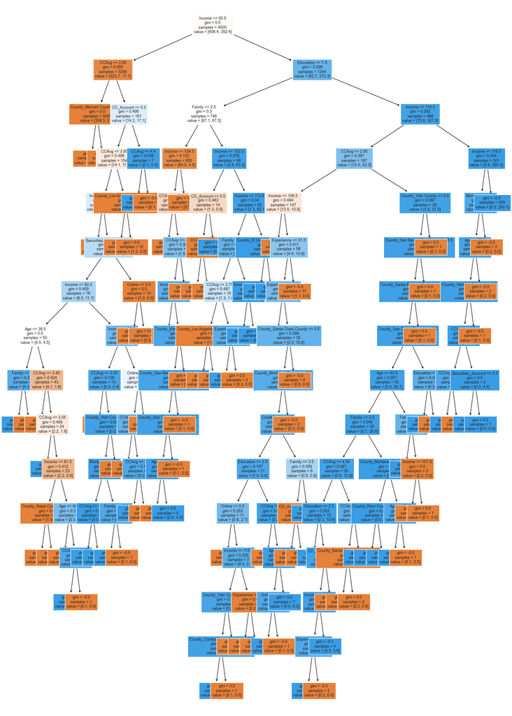

```python
plt.figure(figsize=(20, 30))
out = tree.plot_tree(
    model,
    feature_names=feature_names,
    filled=True,
    fontsize=9,
    node_ids=False,
    class_names=None,
)
# below code will add arrows to the decision tree split if they are missing
for o in out:
    arrow = o.arrow_patch
    if arrow is not None:
        arrow.set_edgecolor("black")
        arrow.set_linewidth(1)
plt.show()
```

#### Observations

The decision tree has multiple nodes, levels and is complex.

```python
# A text report can be generated

print(tree.export_text(model, feature_names=feature_names, show_weights=True))
```

```
|--- Income <= 92.50
|   |--- CCAvg <= 2.95
|   |   |--- County_Merced County <= 0.50
|   |   |   |--- weights: [309.30, 0.00] class: 0
|   |   |--- County_Merced County >  0.50
|   |   |   |--- weights: [0.20, 0.00] class: 0
|   |--- CCAvg >  2.95
|   |   |--- CD_Account <= 0.50
|   |   |   |--- CCAvg <= 3.95
|   |   |   |   |--- Income <= 64.50
|   |   |   |   |   |--- weights: [2.00, 0.00] class: 0
|   |   |   |   |--- Income >  64.50
|   |   |   |   |   |--- Securities_Account <= 0.50
|   |   |   |   |   |   |--- Income <= 82.50
|   |   |   |   |   |   |   |--- Age <= 36.50
|   |   |   |   |   |   |   |   |--- Family <= 3.50
|   |   |   |   |   |   |   |   |   |--- weights: [0.00, 2.70] class: 1
|   |   |   |   |   |   |   |   |--- Family >  3.50
|   |   |   |   |   |   |   |   |   |--- weights: [0.40, 0.00] class: 0
|   |   |   |   |   |   |   |--- Age >  36.50
|   |   |   |   |   |   |   |   |--- CCAvg <= 3.45
|   |   |   |   |   |   |   |   |   |--- weights: [1.90, 0.00] class: 0
|   |   |   |   |   |   |   |   |--- CCAvg >  3.45
|   |   |   |   |   |   |   |   |   |--- CCAvg <= 3.55
|   |   |   |   |   |   |   |   |   |   |--- weights: [0.00, 0.90] class: 1
|   |   |   |   |   |   |   |   |   |--- CCAvg >  3.55
|   |   |   |   |   |   |   |   |   |   |--- Income <= 81.50
|   |   |   |   |   |   |   |   |   |   |   |--- truncated branch of depth 2
|   |   |   |   |   |   |   |   |   |   |--- Income >  81.50
|   |   |   |   |   |   |   |   |   |   |   |--- truncated branch of depth 3
|   |   |   |   |   |   |--- Income >  82.50
|   |   |   |   |   |   |   |--- Income <= 83.50
|   |   |   |   |   |   |   |   |--- CCAvg <= 3.05
|   |   |   |   |   |   |   |   |   |--- weights: [0.20, 0.00] class: 0
|   |   |   |   |   |   |   |   |--- CCAvg >  3.05
|   |   |   |   |   |   |   |   |   |--- County_Yolo County <= 0.50
|   |   |   |   |   |   |   |   |   |   |--- Mortgage <= 0.50
|   |   |   |   |   |   |   |   |   |   |   |--- truncated branch of depth 2
|   |   |   |   |   |   |   |   |   |   |--- Mortgage >  0.50
|   |   |   |   |   |   |   |   |   |   |   |--- truncated branch of depth 2
```

[output cut: 159 more lines]

```
|   |   |   |   |   |   |   |   |--- CCAvg >  0.65
|   |   |   |   |   |   |   |   |   |--- weights: [0.10, 0.00] class: 0
|   |   |   |   |   |   |   |--- CCAvg >  1.00
|   |   |   |   |   |   |   |   |--- Securities_Account <= 0.50
|   |   |   |   |   |   |   |   |   |--- weights: [0.00, 3.60] class: 1
|   |   |   |   |   |   |   |   |--- Securities_Account >  0.50
|   |   |   |   |   |   |   |   |   |--- weights: [0.00, 0.90] class: 1
|   |   |   |   |   |   |--- County_Ventura County >  0.50
|   |   |   |   |   |   |   |--- weights: [0.10, 0.00] class: 0
|   |   |   |   |   |--- Age >  57.50
|   |   |   |   |   |   |--- weights: [0.20, 0.00] class: 0
|   |   |   |   |--- Mortgage >  0.50
|   |   |   |   |   |--- weights: [0.20, 0.00] class: 0
|   |   |   |--- Income >  116.50
|   |   |   |   |--- weights: [0.00, 260.10] class: 1
```

#### Observations

However, a text report for such a complex decision tree is hard to parse as well.

```python
# We can analyze which features were important in the tree building (based on Gini importance)

print(
    pd.DataFrame(
        model.feature_importances_, columns=["Imp"], index=X_train.columns
    ).sort_values(by="Imp", ascending=False)
)
```

```
                                        Imp
Income                         6.330948e-01
Family                         1.412740e-01
Education                      9.833365e-02
CCAvg                          8.816513e-02
CD_Account                     9.460248e-03
Experience                     8.351466e-03
Age                            5.952162e-03
Online                         4.400660e-03
County_Santa Clara County      2.140784e-03
Securities_Account             1.962251e-03
County_Yolo County             1.381728e-03
County_San Bernardino County   9.101973e-04
Mortgage                       8.804308e-04
County_Monterey County         8.070247e-04
County_San Diego County        5.958481e-04
County_Contra Costa County     4.830155e-04
County_Ventura County          4.742334e-04
County_Santa Barbara County    4.633988e-04
CreditCard                     4.377294e-04
County_Kern County             4.312639e-04
County_Merced County           1.652333e-14
County_Los Angeles County      4.130275e-16
County_El Dorado County        4.654693e-17
County_Napa County             2.113242e-18
County_San Luis Obispo County  0.000000e+00
County_Siskiyou County         0.000000e+00
County_Shasta County           0.000000e+00
County_Santa Cruz County       0.000000e+00
County_Solano County           0.000000e+00
County_Sonoma County           0.000000e+00
County_Stanislaus County       0.000000e+00
County_Trinity County          0.000000e+00
County_Tuolumne County         0.000000e+00
County_San Mateo County        0.000000e+00
County_Butte County            0.000000e+00
County_San Joaquin County      0.000000e+00
County_San Francisco County    0.000000e+00
County_Sacramento County       0.000000e+00
County_Riverside County        0.000000e+00
County_Placer County           0.000000e+00
County_Orange County           0.000000e+00
County_Mendocino County        0.000000e+00
County_Marin County            0.000000e+00
County_Lake County             0.000000e+00
County_Imperial County         0.000000e+00
County_Humboldt County         0.000000e+00
County_Fresno County           0.000000e+00
County_San Benito County       0.000000e+00
```

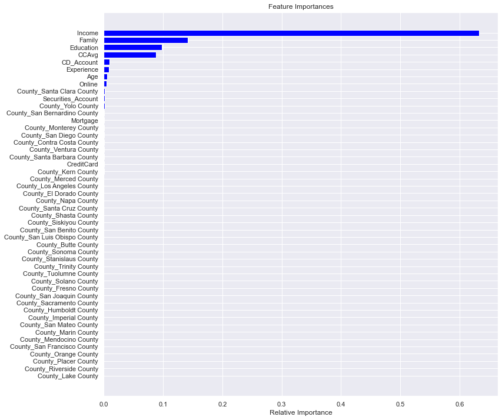

```python
# The same information above can be depicted graphically
importances = model.feature_importances_
indices = np.argsort(importances)

plt.figure(figsize=(12, 12))
plt.title("Feature Importances")
plt.barh(range(len(indices)), importances[indices], color="blue", align="center")
plt.yticks(range(len(indices)), [feature_names[i] for i in indices])
plt.xlabel("Relative Importance")
plt.show()
```

#### Observations

Note: Our next approach to improve the decision tree model will be to tune the hyperparameters. Hyperparameters are specified before the algorithm starts. For this analysis, GridSearchCV, which uses cross validation, will be used for hyperparameter tuning.

```python
# Choose the type of classifier.
estimator = DecisionTreeClassifier(random_state=1, class_weight={0: 0.10, 1: 0.9})

# Grid of parameters to choose from
parameters = {
    "max_depth": [5, 10, 15, None],
    "criterion": ["entropy", "gini"],
    "splitter": ["best", "random"],
    "min_impurity_decrease": [0.00001, 0.0001, 0.01],
}

# We will use recall as the scoring mechanism for perfomance metric
scorer = make_scorer(recall_score)

# Run the grid search
grid_obj = GridSearchCV(estimator, parameters, scoring=scorer, cv=5)
grid_obj = grid_obj.fit(X_train, y_train)

# Set the clf to the best combination of parameters
estimator = grid_obj.best_estimator_

# Fit the best algorithm to the data.
estimator.fit(X_train, y_train)
```

```
DecisionTreeClassifier(class_weight={0: 0.1, 1: 0.9}, max_depth=5,
                       min_impurity_decrease=0.01, random_state=1)
```

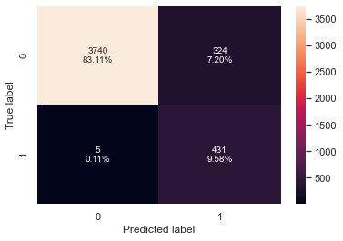

```python
# Generating confusion matrix for decision tree model on training data set
confusion_matrix_sklearn(estimator, X_train, y_train)
```

#### Observations

```python
# Generating performance metrics for training data for decision tree with hyperparameter tuning
decision_tree_tune_perf_train = model_performance_classification_sklearn1(
    estimator, X_train, y_train
)
print("Training performance:")
decision_tree_tune_perf_train
```

```
Training performance:
```

|  | Accuracy | Recall | Precision | F1 |
| --- | --- | --- | --- | --- |
| 0 | 0.926889 | 0.988532 | 0.570861 | 0.723762 |

#### Observations

While the recall score is high (98.8%), we can see that precision and F1 scores are much less. This is for the training set.

```python
##  Function to calculate accuracy, recall, precision and F1 (no threshold)
def model_performance_classification_sklearn1(model, predictors, target):
    """
    model: classifier
    predictors: independent variables
    target: dependent variable

    """
    pred = model.predict(predictors)
    acc = accuracy_score(target, pred)  # to compute Accuracy
    recall = recall_score(target, pred)  # to compute Recall
    precision = precision_score(target, pred)  # to compute Precision
    f1 = f1_score(target, pred)  # to compute F1-score

    # creating a dataframe of metrics
    df_perf = pd.DataFrame(
        {
            "Accuracy": acc,
            "Recall": recall,
            "Precision": precision,
            "F1": f1,
        },
        index=[0],
    )

    return df_perf
```

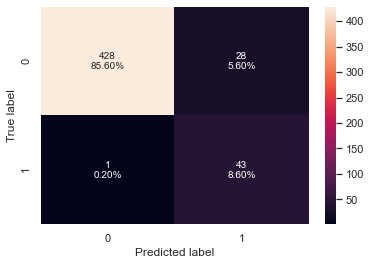

```python
# Generating confusion matrix for testing set for decision tree with hyperparameter tuning
confusion_matrix_sklearn(estimator, X_test, y_test)
```

#### Observations

1. The true positives (Predicted label = 1, True label = 1) = 8.6%.
2. The true negatives (Predicted label = 0, True label = 0) = 85.6%
3. False positives = 5.6% and False negatives = 0.2%.

```python
decision_tree_tune_perf_test = model_performance_classification_sklearn1(
    estimator, X_test, y_test
)
print("Testing performance:")
decision_tree_tune_perf_test
```

```
Testing performance:
```

|  | Accuracy | Recall | Precision | F1 |
| --- | --- | --- | --- | --- |
| 0 | 0.942 | 0.977273 | 0.605634 | 0.747826 |

#### Observations

While the recall score is high (97.7%), we can see that precision and F1 scores are much less. This is for the testing set. However, these scores are close to the training set for decision tree with GridSearch.

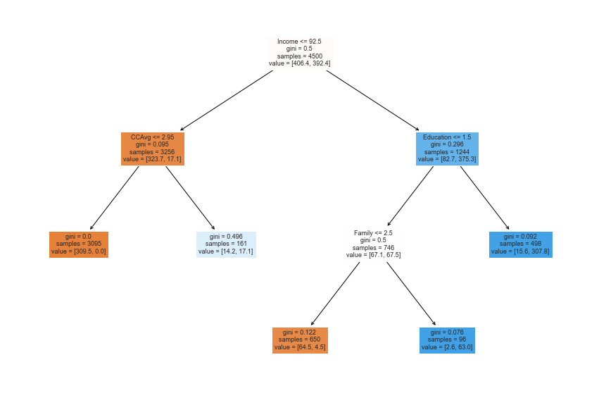

```python
# Visualizing the decision tree with the hyperparameter tuning
plt.figure(figsize=(15, 10))
out = tree.plot_tree(
    estimator,
    feature_names=feature_names,
    filled=True,
    fontsize=9,
    node_ids=False,
    class_names=None,
)
for o in out:
    arrow = o.arrow_patch
    if arrow is not None:
        arrow.set_edgecolor("black")
        arrow.set_linewidth(1)
plt.show()
```

#### Observation

We can see the decision tree with hyperparameters that are tuned has a lot less levels than the default decision tree.

If the income of the customer is less than or equal to 92,500 dollars per annum, and the CCAvg is less than 2.95 thousand dollars per month, then the customer is unlikely to take a personal loan from the bank. The other branches can be interpreted similarly.

However, if the income of the customer is less than or equal to 92,500 and the CCAvg is greater than 2.95, then the customer is in class 1 (which is Personal_Loan = 1, which indicates that customer will take a personal loan from the bank).

```python
# Text report of the decision tree with hyperparameter tuning

print(tree.export_text(estimator, feature_names=feature_names, show_weights=True))
```

```
|--- Income <= 92.50
|   |--- CCAvg <= 2.95
|   |   |--- weights: [309.50, 0.00] class: 0
|   |--- CCAvg >  2.95
|   |   |--- weights: [14.20, 17.10] class: 1
|--- Income >  92.50
|   |--- Education <= 1.50
|   |   |--- Family <= 2.50
|   |   |   |--- weights: [64.50, 4.50] class: 0
|   |   |--- Family >  2.50
|   |   |   |--- weights: [2.60, 63.00] class: 1
|   |--- Education >  1.50
|   |   |--- weights: [15.60, 307.80] class: 1
```

#### Observations

The resultant tree is not complex and easy to read as well and see which combination of criteria will put a customer in class 0 or class 1. For example, if customer's income is > 92,500 dollars and their education level is greater than 1 (so either Master's degree or professional/advanced degree), then the customer is likelier to take a personal loan from the bank.

```python
# Features that are important in the decision tree with hyperparameter tuning

print(
    pd.DataFrame(
        estimator.feature_importances_, columns=["Imp"], index=X_train.columns
    ).sort_values(by="Imp", ascending=False)
)
```

```
                                    Imp
Income                         0.678857
Family                         0.158200
Education                      0.113133
CCAvg                          0.049810
Age                            0.000000
County_Santa Clara County      0.000000
County_Sacramento County       0.000000
County_San Benito County       0.000000
County_San Bernardino County   0.000000
County_San Diego County        0.000000
County_San Francisco County    0.000000
County_San Joaquin County      0.000000
County_San Luis Obispo County  0.000000
County_San Mateo County        0.000000
County_Santa Barbara County    0.000000
County_Shasta County           0.000000
County_Santa Cruz County       0.000000
County_Placer County           0.000000
County_Siskiyou County         0.000000
County_Solano County           0.000000
County_Sonoma County           0.000000
County_Stanislaus County       0.000000
County_Trinity County          0.000000
County_Tuolumne County         0.000000
County_Ventura County          0.000000
County_Riverside County        0.000000
County_Napa County             0.000000
County_Orange County           0.000000
County_Fresno County           0.000000
Mortgage                       0.000000
Securities_Account             0.000000
CD_Account                     0.000000
Online                         0.000000
CreditCard                     0.000000
County_Butte County            0.000000
County_Contra Costa County     0.000000
County_El Dorado County        0.000000
County_Humboldt County         0.000000
Experience                     0.000000
County_Imperial County         0.000000
County_Kern County             0.000000
County_Lake County             0.000000
County_Los Angeles County      0.000000
County_Marin County            0.000000
County_Mendocino County        0.000000
County_Merced County           0.000000
County_Monterey County         0.000000
County_Yolo County             0.000000
```

#### Observations

Income, Family, Education and CCAvg are the factors that are most important for the decision tree with hyperparameter tuning.

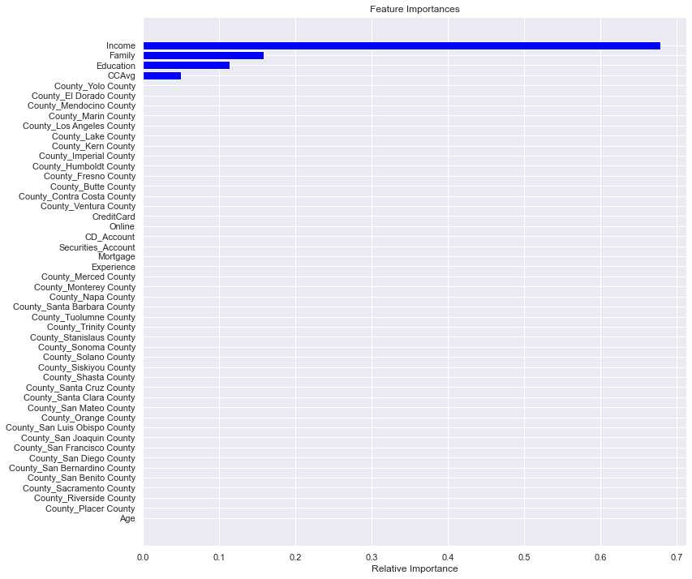

```python
# Visualization of the same feature importance as above
importances = estimator.feature_importances_
indices = np.argsort(importances)

plt.figure(figsize=(12, 12))
plt.title("Feature Importances")
plt.barh(range(len(indices)), importances[indices], color="blue", align="center")
plt.yticks(range(len(indices)), [feature_names[i] for i in indices])
plt.xlabel("Relative Importance")
plt.show()
```